# 01b_id_parent_and_shift

## 01b_id_parent_and_shift

#### Question

1. Below are some common parent functions.

   | names | expressions |
   | --- | --- |
   | absolute value | $f(x)=\lvert x \rvert$ |
   | quadratic | $f(x)=x^2$ |
   | cubic | $f(x)=x^3$ |
   | reciprocal | $f(x)=\frac{1}{x}$ |
   | square root | $f(x)=\sqrt{x}$ |
   | cube root | $f(x)=\sqrt[3]{x}$ |
   | exponential | $f(x)=2^{x}$ |
   | logarithmic | $f(x)=\log_{2}(x)$ |

   One of those parent functions has been translated (shifted) to produce the graph below:

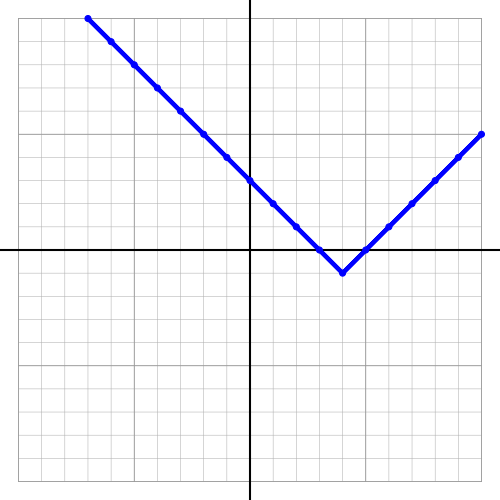

   - Which parent function was used?
   - What translation was used?

#### Solution

#### Question

2. Below are some common parent functions.

   | names | expressions |
   | --- | --- |
   | absolute value | $f(x)=\lvert x \rvert$ |
   | quadratic | $f(x)=x^2$ |
   | cubic | $f(x)=x^3$ |
   | reciprocal | $f(x)=\frac{1}{x}$ |
   | square root | $f(x)=\sqrt{x}$ |
   | cube root | $f(x)=\sqrt[3]{x}$ |
   | exponential | $f(x)=2^{x}$ |
   | logarithmic | $f(x)=\log_{2}(x)$ |

   One of those parent functions has been translated (shifted) to produce the graph below:

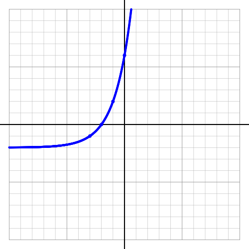

   - Which parent function was used?
   - What translation was used?

#### Solution

#### Question

3. Below are some common parent functions.

   | names | expressions |
   | --- | --- |
   | absolute value | $f(x)=\lvert x \rvert$ |
   | quadratic | $f(x)=x^2$ |
   | cubic | $f(x)=x^3$ |
   | reciprocal | $f(x)=\frac{1}{x}$ |
   | square root | $f(x)=\sqrt{x}$ |
   | cube root | $f(x)=\sqrt[3]{x}$ |
   | exponential | $f(x)=2^{x}$ |
   | logarithmic | $f(x)=\log_{2}(x)$ |

   One of those parent functions has been translated (shifted) to produce the graph below:

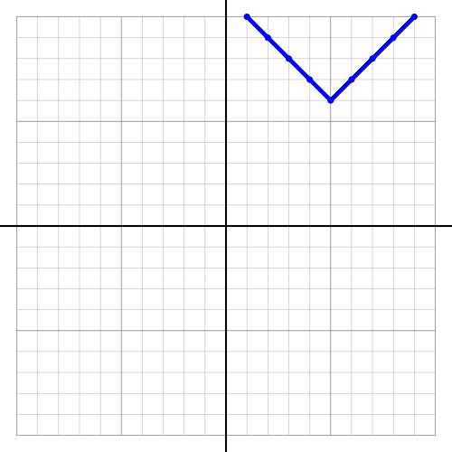

   - Which parent function was used?
   - What translation was used?

#### Solution

#### Question

4. Below are some common parent functions.

   | names | expressions |
   | --- | --- |
   | absolute value | $f(x)=\lvert x \rvert$ |
   | quadratic | $f(x)=x^2$ |
   | cubic | $f(x)=x^3$ |
   | reciprocal | $f(x)=\frac{1}{x}$ |
   | square root | $f(x)=\sqrt{x}$ |
   | cube root | $f(x)=\sqrt[3]{x}$ |
   | exponential | $f(x)=2^{x}$ |
   | logarithmic | $f(x)=\log_{2}(x)$ |

   One of those parent functions has been translated (shifted) to produce the graph below:

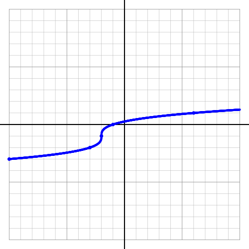

   - Which parent function was used?
   - What translation was used?

#### Solution

#### Question

5. Below are some common parent functions.

   | names | expressions |
   | --- | --- |
   | absolute value | $f(x)=\lvert x \rvert$ |
   | quadratic | $f(x)=x^2$ |
   | cubic | $f(x)=x^3$ |
   | reciprocal | $f(x)=\frac{1}{x}$ |
   | square root | $f(x)=\sqrt{x}$ |
   | cube root | $f(x)=\sqrt[3]{x}$ |
   | exponential | $f(x)=2^{x}$ |
   | logarithmic | $f(x)=\log_{2}(x)$ |

   One of those parent functions has been translated (shifted) to produce the graph below:

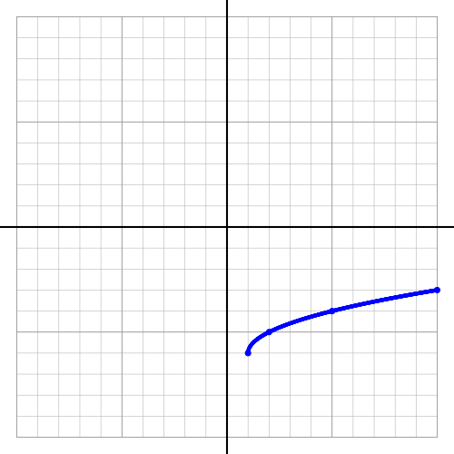

   - Which parent function was used?
   - What translation was used?

#### Solution

#### Question

6. Below are some common parent functions.

   | names | expressions |
   | --- | --- |
   | absolute value | $f(x)=\lvert x \rvert$ |
   | quadratic | $f(x)=x^2$ |
   | cubic | $f(x)=x^3$ |
   | reciprocal | $f(x)=\frac{1}{x}$ |
   | square root | $f(x)=\sqrt{x}$ |
   | cube root | $f(x)=\sqrt[3]{x}$ |
   | exponential | $f(x)=2^{x}$ |
   | logarithmic | $f(x)=\log_{2}(x)$ |

   One of those parent functions has been translated (shifted) to produce the graph below:

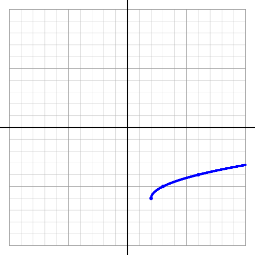

   - Which parent function was used?
   - What translation was used?

#### Solution

#### Question

7. Below are some common parent functions.

   | names | expressions |
   | --- | --- |
   | absolute value | $f(x)=\lvert x \rvert$ |
   | quadratic | $f(x)=x^2$ |
   | cubic | $f(x)=x^3$ |
   | reciprocal | $f(x)=\frac{1}{x}$ |
   | square root | $f(x)=\sqrt{x}$ |
   | cube root | $f(x)=\sqrt[3]{x}$ |
   | exponential | $f(x)=2^{x}$ |
   | logarithmic | $f(x)=\log_{2}(x)$ |

   One of those parent functions has been translated (shifted) to produce the graph below:

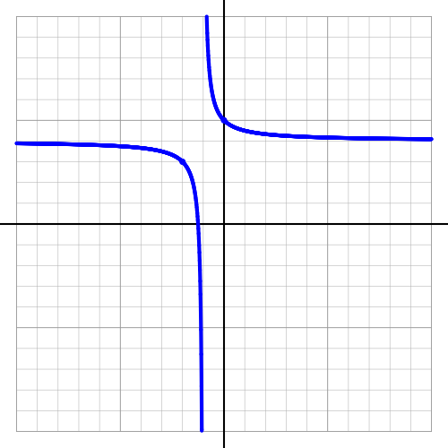

   - Which parent function was used?
   - What translation was used?

#### Solution

#### Question

8. Below are some common parent functions.

   | names | expressions |
   | --- | --- |
   | absolute value | $f(x)=\lvert x \rvert$ |
   | quadratic | $f(x)=x^2$ |
   | cubic | $f(x)=x^3$ |
   | reciprocal | $f(x)=\frac{1}{x}$ |
   | square root | $f(x)=\sqrt{x}$ |
   | cube root | $f(x)=\sqrt[3]{x}$ |
   | exponential | $f(x)=2^{x}$ |
   | logarithmic | $f(x)=\log_{2}(x)$ |

   One of those parent functions has been translated (shifted) to produce the graph below:

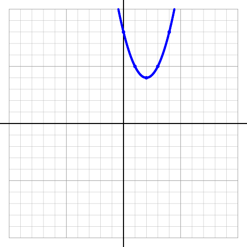

   - Which parent function was used?
   - What translation was used?

#### Solution

#### Question

9. Below are some common parent functions.

   | names | expressions |
   | --- | --- |
   | absolute value | $f(x)=\lvert x \rvert$ |
   | quadratic | $f(x)=x^2$ |
   | cubic | $f(x)=x^3$ |
   | reciprocal | $f(x)=\frac{1}{x}$ |
   | square root | $f(x)=\sqrt{x}$ |
   | cube root | $f(x)=\sqrt[3]{x}$ |
   | exponential | $f(x)=2^{x}$ |
   | logarithmic | $f(x)=\log_{2}(x)$ |

   One of those parent functions has been translated (shifted) to produce the graph below:

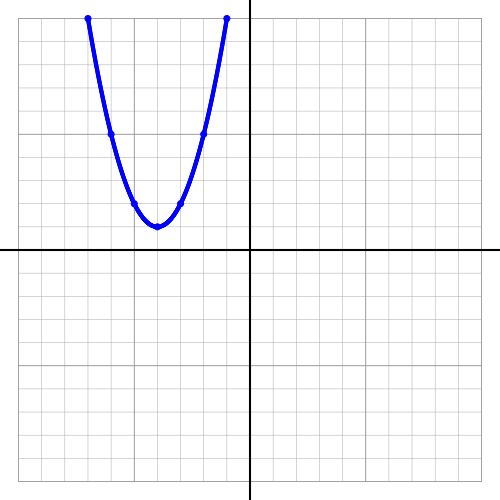

   - Which parent function was used?
   - What translation was used?

#### Solution

#### Question

10. Below are some common parent functions.

    | names | expressions |
    | --- | --- |
    | absolute value | $f(x)=\lvert x \rvert$ |
    | quadratic | $f(x)=x^2$ |
    | cubic | $f(x)=x^3$ |
    | reciprocal | $f(x)=\frac{1}{x}$ |
    | square root | $f(x)=\sqrt{x}$ |
    | cube root | $f(x)=\sqrt[3]{x}$ |
    | exponential | $f(x)=2^{x}$ |
    | logarithmic | $f(x)=\log_{2}(x)$ |

    One of those parent functions has been translated (shifted) to produce the graph below:

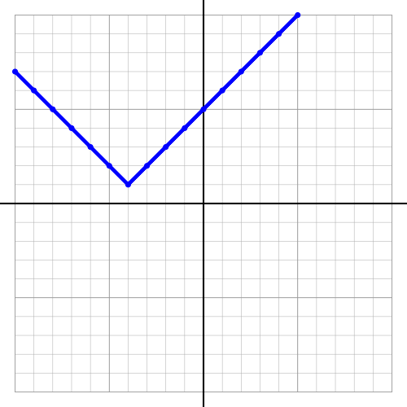

    - Which parent function was used?
    - What translation was used?

#### Solution

#### Question

11. Below are some common parent functions.

    | names | expressions |
    | --- | --- |
    | absolute value | $f(x)=\lvert x \rvert$ |
    | quadratic | $f(x)=x^2$ |
    | cubic | $f(x)=x^3$ |
    | reciprocal | $f(x)=\frac{1}{x}$ |
    | square root | $f(x)=\sqrt{x}$ |
    | cube root | $f(x)=\sqrt[3]{x}$ |
    | exponential | $f(x)=2^{x}$ |
    | logarithmic | $f(x)=\log_{2}(x)$ |

    One of those parent functions has been translated (shifted) to produce the graph below:

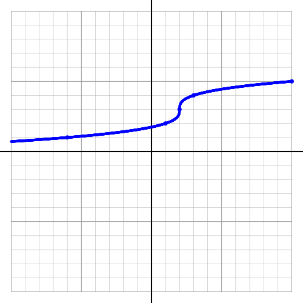

    - Which parent function was used?
    - What translation was used?

#### Solution

#### Question

12. Below are some common parent functions.

    | names | expressions |
    | --- | --- |
    | absolute value | $f(x)=\lvert x \rvert$ |
    | quadratic | $f(x)=x^2$ |
    | cubic | $f(x)=x^3$ |
    | reciprocal | $f(x)=\frac{1}{x}$ |
    | square root | $f(x)=\sqrt{x}$ |
    | cube root | $f(x)=\sqrt[3]{x}$ |
    | exponential | $f(x)=2^{x}$ |
    | logarithmic | $f(x)=\log_{2}(x)$ |

    One of those parent functions has been translated (shifted) to produce the graph below:

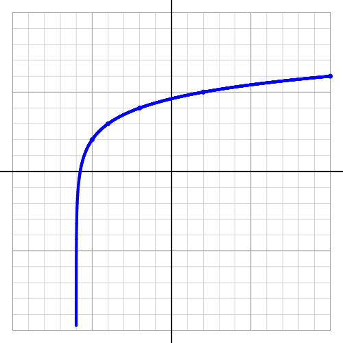

    - Which parent function was used?
    - What translation was used?

#### Solution